# BMIN503/EPID600 Car Crashes in Philadelphia in 2008 and 2018

Nuoying MA

Use this template to complete your project throughout the course. Your Final Project presentation in class will be based on the contents of this document. Replace the title/name and text below with your own, but keep the headers.

### Overview

In this section, give a brief a description of your project and its goal, what data you are using to complete it, and what three faculty/staff in different fields you have spoken to about your project with a brief summary of what you learned from each person. Include a link to your final project GitHub repository.

The goal is to examine car crash data in Philadelphia in 2008 and 2018, respectively. This project will first obtain important objective factors related to crashes. This project will then obtain and compare the critical factors contributing the fatal or major injury resulting car crashes in 2008 and 2018 using machine learning methods (random forest and logistic regression). Then, the important objective factors contributing to the car crashes will be plotted. My Repo: [Nuoying final project][https://github.com/Nuoying/BMIN503_Final_Project]

### Introduction

In the first paragraph, describe the problem addressed, its significance, and some background to motivate the problem.

This project utilizes the data provided by the Philadelphia government for all crashes in 2008 and 2018. Car crashes can be fatal and detrimental to the families of victims. By finding the most critical factors contributing to fatal or major injury resulting crashes, this project could provide a warning and raise the caution to drivers and pedestrians of those factors, and potentially reduce the fatal rate of accidents.

Since the car crash data also contains information on observed dangerous driving behaviors, including alcohol consumption, speeding, this data would be useful to study the effect of human psychology and health status on the severity of accidents.

### Methods & Results

In the first paragraph, describe the data used and general methodological approach. Subsequently, incorporate full R code necessary to retrieve and clean data, and perform analysis. Be sure to include a description of code so that others (including your future self) can understand what you are doing and why.

I extract the Philadelphia crashes dataset for 2008 and 2018 from Pennsylvania Crash Information Tool (PCIT), the publicly available crash datasets. The website also allows users to visualise the locations of crashes. Since the dataset I obtained did not contains FIPS code, I did not create leaflet maps. From all the possible datasets, I focused on Philadelphia crashes, and compare 2008 data with 2018 data.

```r
#install all needed package here.
#install.packages('lattice')
#install.packages('caret')
#install.packages('varhandle')
library(ggplot2)
My_Theme = theme(
  axis.title.x = element_text(size = 16),
  axis.text.x = element_text(size = 14),
  axis.title.y = element_text(size = 16)) #increase the font size for axis
My_Theme.2 = theme(
  axis.title.x = element_text(size = 16),
  axis.text.x = element_text(size = 5),#decrease the font size for x-axis
  axis.title.y = element_text(size = 16))
My_Theme.3 = theme(
  axis.title.x = element_text(size = 16),
  axis.text.x = element_text(size = 16),
  axis.text.y = element_text(size = 5))#decrease the font size for x-axis
```

```r
getwd()
```

```
## [1] "/Users/manuoying/Desktop/BMIN 503/BMIN503_Final_Project_Nuoying"
```

```r
library(ggplot2)
library(dplyr)
flag.2018 <- read.csv("Philadelphia_FLAG_2018.csv", header = TRUE) #load 2018 flag data
crash.2018 <- read.csv("CRASH_2018_Philadelphia.csv", header = TRUE) #load 2018 flag data

crash.2008<-read.csv("CRASH_2008_Philadelphia.csv", header=TRUE)
flag.2008<-read.csv("FLAG_2008_Philadelphia.csv", header=TRUE) #load 2008 flag data, look for most important factors contributing to fatal car crashes.
crash.08 <- crash.2008 %>%
             select(POLICE_AGCY, ARRIVAL_TM, DISPATCH_TM, CRN, CRASH_YEAR,DAY_OF_WEEK, HOUR_OF_DAY,FATAL_COUNT, INJURY_COUNT, PERSON_COUNT, ROAD_CONDITION, ILLUMINATION, WEATHER, COLLISION_TYPE, RELATION_TO_ROAD, TCD_FUNC_CD)

#We would like to find out important factors contributing to fatal/major injury containing crashes.
flagu.18<-flag.2018 %>%
  select_if(~n_distinct(.) > 1)#We first need to exclude columns with only 1 value (otherwise cause error in logistic regression)
colnames(flagu.18)
```

```
##   [1] "CRN"                       "POLICE_AGCY_NAME"          "POLICE_AGCY"               "CRASH_MONTH"               "DAY_OF_WEEK"               "TIME_OF_DAY"               "HOUR_OF_DAY"               "ILLUMINATION"              "WEATHER"                   "ROAD_CONDITION"            "COLLISION_…
##  [15] "TCD_TYPE"                  "FATAL_COUNT"               "INJURY_COUNT"              "PERSON_COUNT"              "TOTAL_UNITS"               "SCH_BUS_IND"               "SCH_ZONE_IND"              "LATITUDE"                  "LONGITUDE"                 "ARRIVAL_TM"                "CONS_ZONE_…
##  [29] "LN_CLOSE_DIR"              "SPEC_JURIS_CD"             "TCD_FUNC_CD"               "WORKERS_PRES"              "WZ_CLOSE_DETOUR"           "WZ_FLAGGER"                "WZ_LAW_OFFCR_IND"          "WZ_LN_CLOSURE"             "WZ_MOVING"                 "WZ_OTHER"                  "WZ_SHLDER_…
##  [43] "BUS_COUNT"                 "SMALL_TRUCK_COUNT"         "HEAVY_TRUCK_COUNT"         "SUV_COUNT"                 "VAN_COUNT"                 "BICYCLE_COUNT"             "MAJ_INJ_COUNT"             "MOD_INJ_COUNT"             "MIN_INJ_COUNT"             "TOT_INJ_COUNT"             "UNK_INJ_DE…
##  [57] "DRIVER_COUNT_18YR"         "DRIVER_COUNT_19YR"         "DRIVER_COUNT_20YR"         "DRIVER_COUNT_50_64YR"      "DRIVER_COUNT_65_74YR"      "DRIVER_COUNT_75PLUS"       "UNBELTED_OCC_COUNT"        "UNB_DEATH_COUNT"           "UNB_MAJ_INJ_COUNT"         "BELTED_DEATH_COUNT"        "BELTED_MAJ…
##  [71] "BICYCLE_MAJ_INJ_COUNT"     "PED_COUNT"                 "PED_DEATH_COUNT"           "PED_MAJ_INJ_COUNT"         "MAX_SEVERITY_LEVEL"        "COMM_VEH_COUNT"            "DEC_LAT"                   "DEC_LONG"                  "RDWY_SURF_TYPE_CD"         "INTERSTATE"                "STATE_ROAD…
##  [85] "ICY_ROAD"                  "SUDDEN_DEER"               "SHLDR_RELATED"             "REAR_END"                  "HO_OPPDIR_SDSWP"           "HIT_FIXED_OBJECT"          "SV_RUN_OFF_RD"             "WORK_ZONE"                 "PROPERTY_DAMAGE_ONLY"      "INJURY_OR_FATAL"           "FATAL_OR_M…
##  [99] "INTERSECTION"              "SIGNALIZED_INT"            "STOP_CONTROLLED_INT"       "UNSIGNALIZED_INT"          "SCHOOL_BUS"                "SCHOOL_ZONE"               "HIT_DEER"                  "HIT_TREE_SHRUB"            "HIT_EMBANKMENT"            "HIT_POLE"                  "HIT_GDRAIL…
## [113] "OVERTURNED"                "MOTORCYCLE"                "BICYCLE"                   "HVY_TRUCK_RELATED"         "VEHICLE_FAILURE"           "TRAIN_TROLLEY"             "PHANTOM_VEHICLE"           "ALCOHOL_RELATED"           "DRINKING_DRIVER"           "UNDERAGE_DRNK_DRV"         "UNLICENSED…
## [127] "RUNNING_RED_LT"            "TAILGATING"                "CROSS_MEDIAN"              "CURVED_ROAD"               "CURVE_DVR_ERROR"           "LIMIT_65MPH"               "SPEEDING"                  "SPEEDING_RELATED"          "AGGRESSIVE_DRIVING"        "FATIGUE_ASLEEP"            "DRIVER_YES…
## [141] "DRIVER_20YR"               "DRIVER_5NO_64YR"           "DRIVER_65_74YR"            "DRIVER_75PLUS"             "UNBELTED"                  "PEDESTRIAN"                "COMM_VEHICLE"              "PSP_REPORTED"              "NHTSA_AGG_DRIVING"         "DEER_RELATED"              "ILLUMINATI…
## [155] "HIT_PARKED_VEHICLE"        "FIRE_IN_VEHICLE"           "VEHICLE_TOWED"             "HAZARDOUS_TRUCK"           "MAJOR_INJURY"              "MODERATE_INJURY"           "MINOR_INJURY"              "MC_DRINKING_DRIVER"        "DRUG_RELATED"              "ILLEGAL_DRUG_RELATED"      "SCHOOL_BUS…
## [169] "SUSPECTED_SERIOUS_INJURY"  "SUSPECTED_MINOR_INJURY"    "POSSIBLE_INJURY"           "LIMIT_70MPH"               "ANGLE_CRASH"               "HORSE_BUGGY"               "ATV"                       "CORE_NETWORK"              "OPIOID_RELATED"            "LANE_DEPARTURE"            "SINGLE_VEH…
## [183] "BACKUP_NONRECURRING"       "BACKUP_CONGESTION"
```

```r
ncol(flagu.18) #184
```

```
## [1] 184
```

```r
df1<-as.vector(colnames(flag.2008))
#95 variables
df2<-as.vector(colnames(flagu.18))
#184 variables
df3<-df2[df2%in%df1]#df2 include 87 variables in df1
df1[!df1%in%df3]#lack"LOCAL_ROAD","TURNPIKE","DRIVER_16YR","DRIVER_50_64YR","CRASH_YEAR","C         OUNTY","COUNTY_YEAR","MUNICIPALITY"
```

```
## [1] "LOCAL_ROAD"     "TURNPIKE"       "DRIVER_16YR"    "DRIVER_50_64YR" "CRASH_YEAR"     "COUNTY"         "COUNTY_YEAR"    "MUNICIPALITY"
```

```r
df2[!df2%in%df1] #df2 has 97 more variables than df1, among them some are worthy to be examined, includes "CRASH_MONTH", "DAY_OF_WEEK","TIME_OF_DAY","HOUR_OF_DAY","WEATHER", "COLLISION_TYPE" , "TCD_TYPE", "LATITUDE", "LONGITUDE","TCD_FUNC_CD", "WZ_CLOSE_DETOUR", "WZ_FLAGGER", "WZ_LAW_OFFCR_IND", "WZ_LN_CLOSURE", "WZ_MOVING", "WZ_OTHER", "WZ_SHLDER_MDN", "DRIVER_5NO_64YR",  "LIMIT_70MPH", "ANGLE_CRASH", "HORSE_BUGGY", "ATV", "CORE_NETWORK", "OPIOID_RELATED", "LANE_DEPARTURE", "BACKUP_PRIOR", "BACKUP_NONRECURRING" ,"BACKUP_CONGESTION"
```

```
##  [1] "POLICE_AGCY_NAME"          "POLICE_AGCY"               "CRASH_MONTH"               "DAY_OF_WEEK"               "TIME_OF_DAY"               "HOUR_OF_DAY"               "ILLUMINATION"              "WEATHER"                   "ROAD_CONDITION"            "COLLISION_TYPE"            "WORK_ZONE_T…
## [15] "FATAL_COUNT"               "INJURY_COUNT"              "PERSON_COUNT"              "TOTAL_UNITS"               "SCH_BUS_IND"               "SCH_ZONE_IND"              "LATITUDE"                  "LONGITUDE"                 "ARRIVAL_TM"                "CONS_ZONE_SPD_LIM"         "DISPATCH_TM…
## [29] "SPEC_JURIS_CD"             "TCD_FUNC_CD"               "WORKERS_PRES"              "WZ_CLOSE_DETOUR"           "WZ_FLAGGER"                "WZ_LAW_OFFCR_IND"          "WZ_LN_CLOSURE"             "WZ_MOVING"                 "WZ_OTHER"                  "WZ_SHLDER_MDN"             "VEHICLE_COU…
## [43] "SMALL_TRUCK_COUNT"         "HEAVY_TRUCK_COUNT"         "SUV_COUNT"                 "VAN_COUNT"                 "BICYCLE_COUNT"             "MAJ_INJ_COUNT"             "MOD_INJ_COUNT"             "MIN_INJ_COUNT"             "TOT_INJ_COUNT"             "UNK_INJ_DEG_COUNT"         "UNK_INJ_PER…
## [57] "DRIVER_COUNT_19YR"         "DRIVER_COUNT_20YR"         "DRIVER_COUNT_50_64YR"      "DRIVER_COUNT_65_74YR"      "DRIVER_COUNT_75PLUS"       "UNBELTED_OCC_COUNT"        "UNB_DEATH_COUNT"           "UNB_MAJ_INJ_COUNT"         "BELTED_DEATH_COUNT"        "BELTED_MAJ_INJ_COUNT"      "MCYCLE_DEAT…
## [71] "PED_COUNT"                 "PED_DEATH_COUNT"           "PED_MAJ_INJ_COUNT"         "MAX_SEVERITY_LEVEL"        "COMM_VEH_COUNT"            "DEC_LAT"                   "DEC_LONG"                  "RDWY_SURF_TYPE_CD"         "DRIVER_YES6YR"             "DRIVER_5NO_64YR"           "FATAL_OR_SU…
## [85] "LIMIT_70MPH"               "ANGLE_CRASH"               "HORSE_BUGGY"               "ATV"                       "CORE_NETWORK"              "OPIOID_RELATED"            "LANE_DEPARTURE"            "SINGLE_VEHICLE"            "MULTIPLE_VEHICLE"          "OTHER_FREEWAY_EXPRESSWAY"  "BACKUP_PRIO…
```

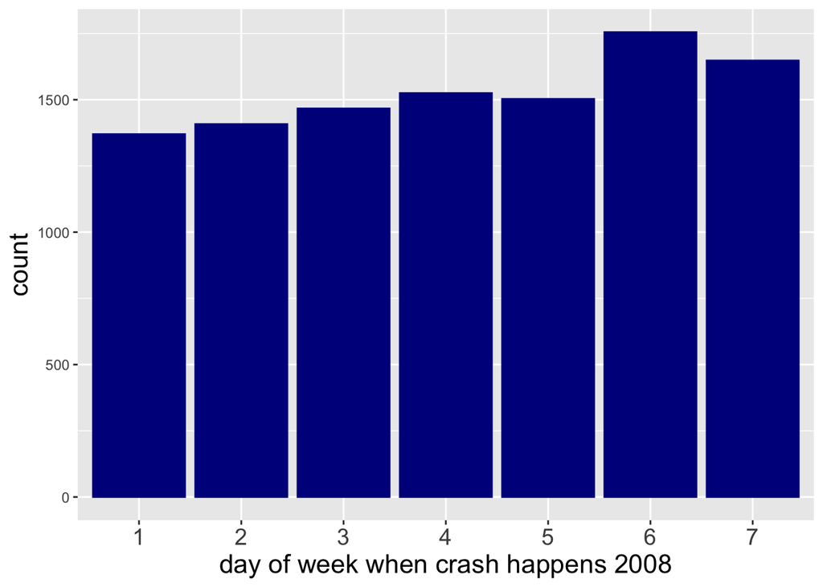

```r
flag.2008$VEHICLE_TOWED<-NULL#this is a variable happens after crashes
flag.2008$COUNTY_YEAR<-NULL

#Look at the distribution of crashes among different situations, 2008 situations
ggplot(data = crash.08, aes(x = factor(DAY_OF_WEEK)))+
  geom_bar(color="darkblue", fill= "darkblue")+
  labs(x = "day of week when crash happens 2008")+
  My_Theme+
  ggsave("dayofweek08.tiff")
```

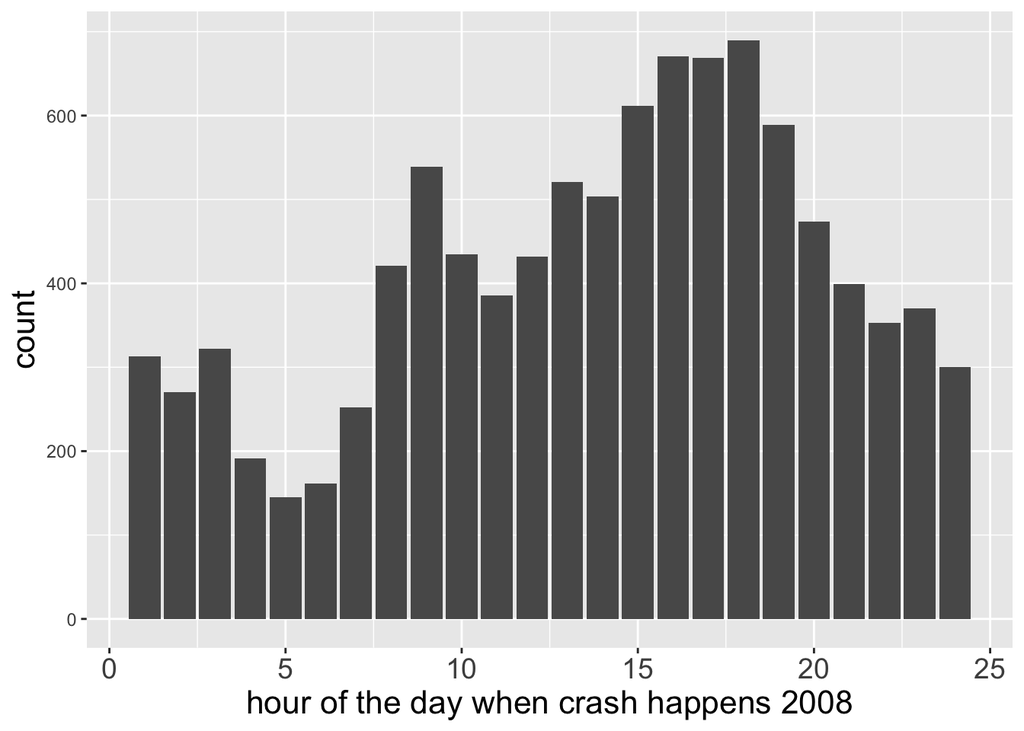

```r
#More crashes happens on Saturday.


crash.08 %>%
    mutate(HOUR_OF_DAY = ifelse(HOUR_OF_DAY %in% c(99), NA,factor(HOUR_OF_DAY))) %>%
    ggplot(aes(x = HOUR_OF_DAY))+
    geom_bar()+
    labs(x = "hour of the day when crash happens 2008")+
    My_Theme+
    ggsave("hourofday08.tiff")
```

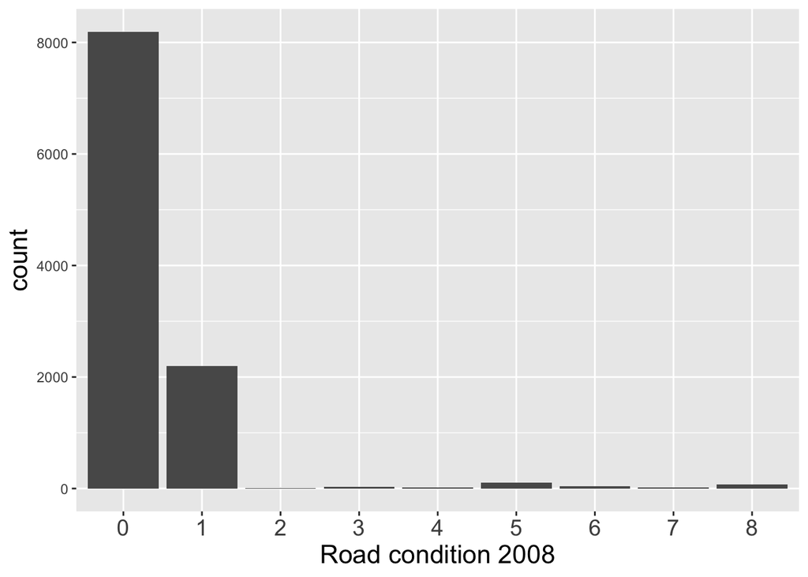

```r
# Peak hour of crashes: from 8-10AM in the morning, and from 5-7PM in the afternoon. Much more likely to happen in the afternoon.

crash.08 %>%
    ggplot(aes(x = factor(ROAD_CONDITION)))+
    geom_bar()+
    labs(x = "Road condition 2008")+
    My_Theme+
    ggsave("Roadcondition08.tiff") #Mostly happens on dry roads, and wet roads are the second contributing factors.
```

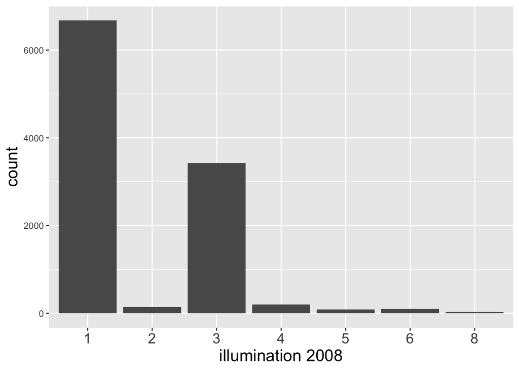

```r
crash.08 %>%
    ggplot(aes(x = factor(ILLUMINATION)))+
    geom_bar()+
    labs(x = "illumination 2008")+
    My_Theme+
    ggsave("illumination08.tiff") #Mostly happens on dry roads, and wet roads are the second contributing factors.
```

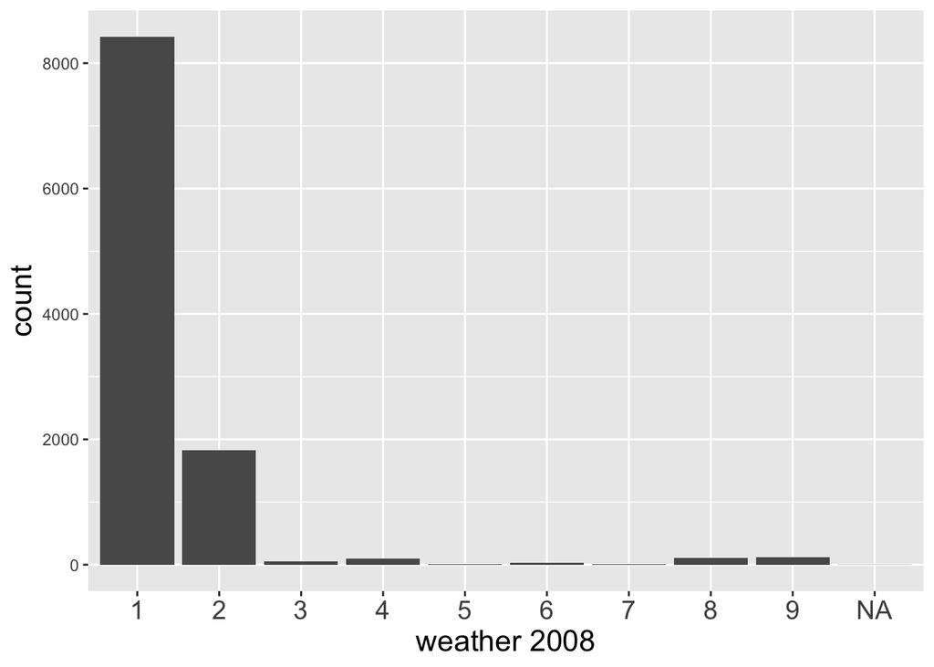

```r
crash.08 %>%
    ggplot(aes(x = factor(WEATHER)))+
    geom_bar()+
    labs(x = "weather 2008")+
    My_Theme+
    ggsave("weather08.tiff")# Mostly no adverse condition, second: rain
```

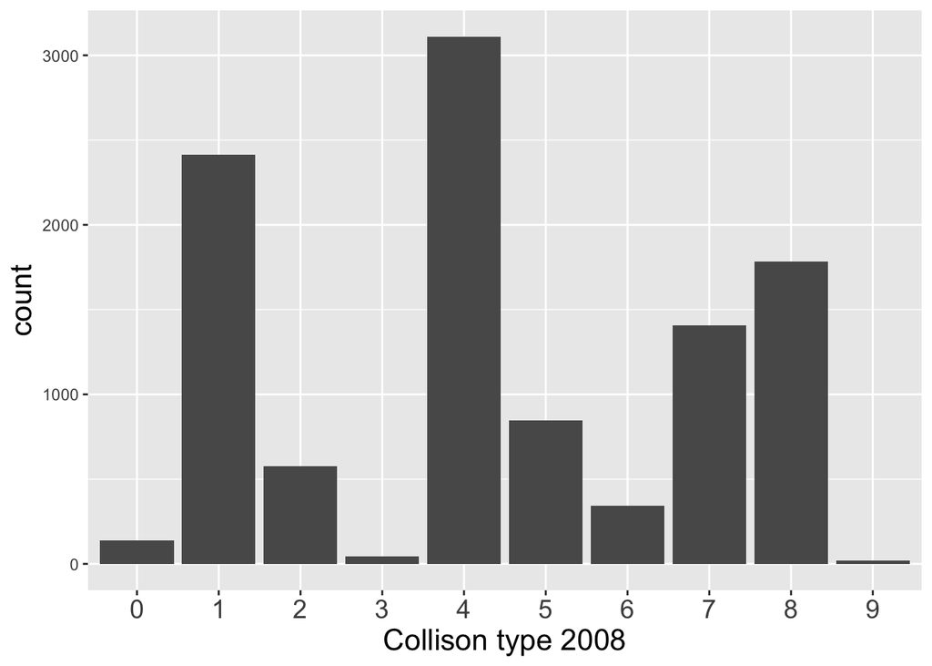

```r
crash.08 %>%
    ggplot(aes(x = factor(COLLISION_TYPE)))+
    geom_bar()+
    labs(x = "Collison type 2008")+
    My_Theme+
    ggsave("Collisontype08.tiff") #Mostly
```

```r
crash.08 %>%
  group_by(COLLISION_TYPE)%>%
  count(COLLISION_TYPE)
```

```
## # A tibble: 10 x 2
## # Groups:   COLLISION_TYPE [10]
##    COLLISION_TYPE     n
##             <int> <int>
##  1              0   139
##  2              1  2413
##  3              2   578
##  4              3    44
##  5              4  3111
##  6              5   845
##  7              6   341
##  8              7  1405
##  9              8  1782
## 10              9    18
```

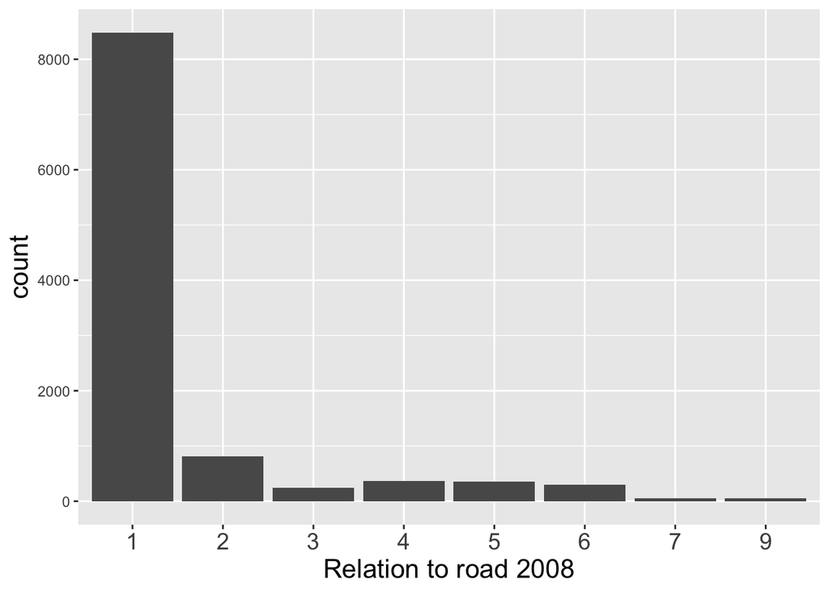

```r
crash.2008 %>%
    ggplot(aes(x = factor(RELATION_TO_ROAD)))+
    geom_bar()+
    labs(x = "Relation to road 2008")+
    My_Theme+
    ggsave("Relation to road 08.tiff") #Mostly on roadway.
```

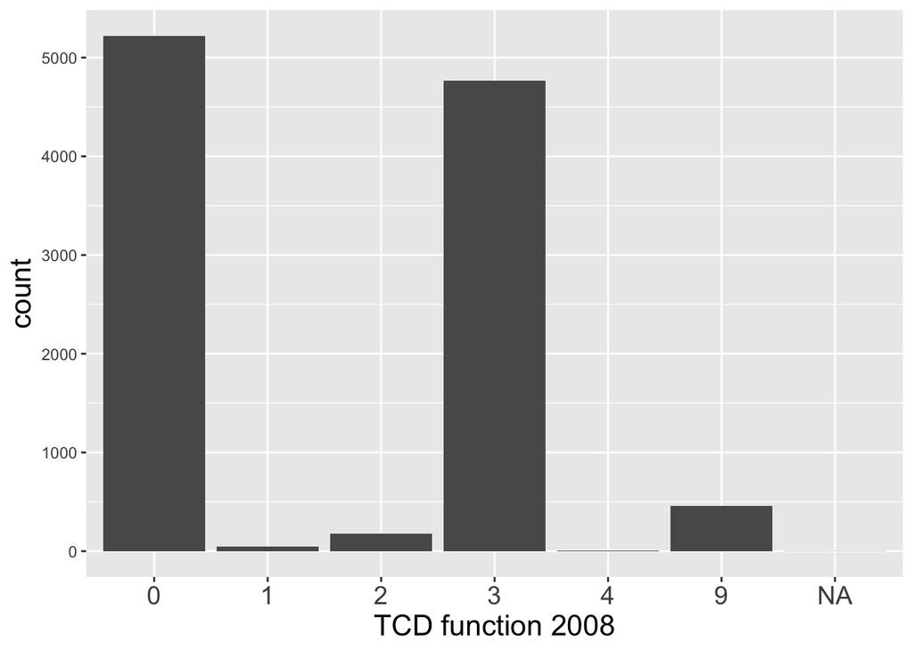

```r
crash.2008 %>%
    ggplot(aes(x = factor(TCD_FUNC_CD)))+
    geom_bar()+
    labs(x = "TCD function 2008")+
    My_Theme+
    ggsave("TCD08.tiff") #About half: with no controls, another half: device functioning properly.
```

```r
crash.2008 %>%
  group_by(TCD_FUNC_CD)%>%
  count(TCD_FUNC_CD)#About 4766/10676=0.45%: with no controls, another 5222/10676=0.49%: device functioning properly.
```

```
## # A tibble: 7 x 2
## # Groups:   TCD_FUNC_CD [7]
##   TCD_FUNC_CD     n
##         <dbl> <int>
## 1           0  5222
## 2           1    44
## 3           2   178
## 4           3  4766
## 5           4     5
## 6           9   459
## 7          NA     2
```

```r
nrow(crash.2008) #10676 accidents.
```

```
## [1] 10676
```

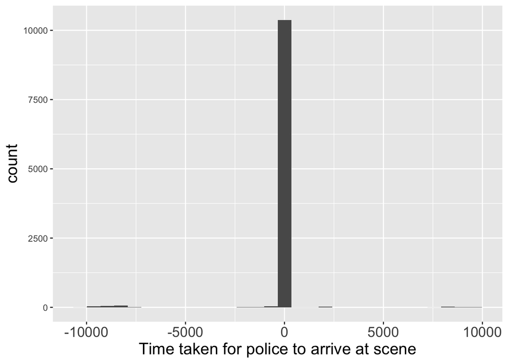

```r
#time difference from police dispatched to police arrived. Mostly 0 minutes, probably not true, not a useful data to include.
crash.2008%>%
    mutate(arrival=DISPATCH_TM-ARRIVAL_TM)%>%
    ggplot(aes(x = arrival))+
    geom_histogram()+
    labs(x = "Time taken for police to arrive at scene")+
    My_Theme+
    ggsave("Time08.tiff")
```

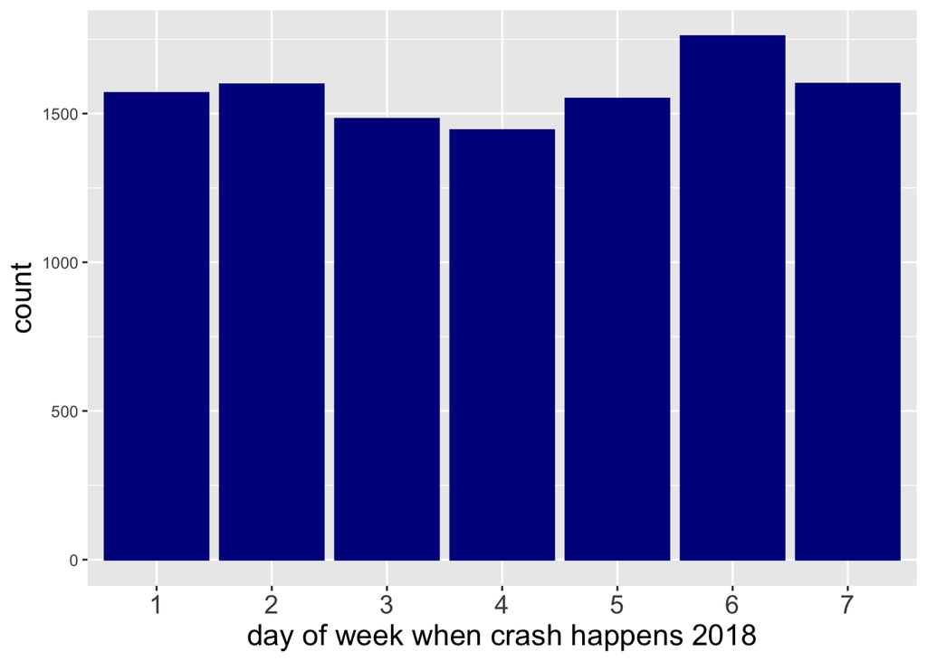

```r
#Look at the distribution of crashes among different situations, 2018 situations
library(ggplot2)
fig1<-ggplot(data = flag.2018, aes(x = factor(DAY_OF_WEEK)))+
  geom_bar(color="darkblue", fill= "darkblue")+
  labs(x = "day of week when crash happens 2018")+
  My_Theme
fig1#summarise by day of week
```

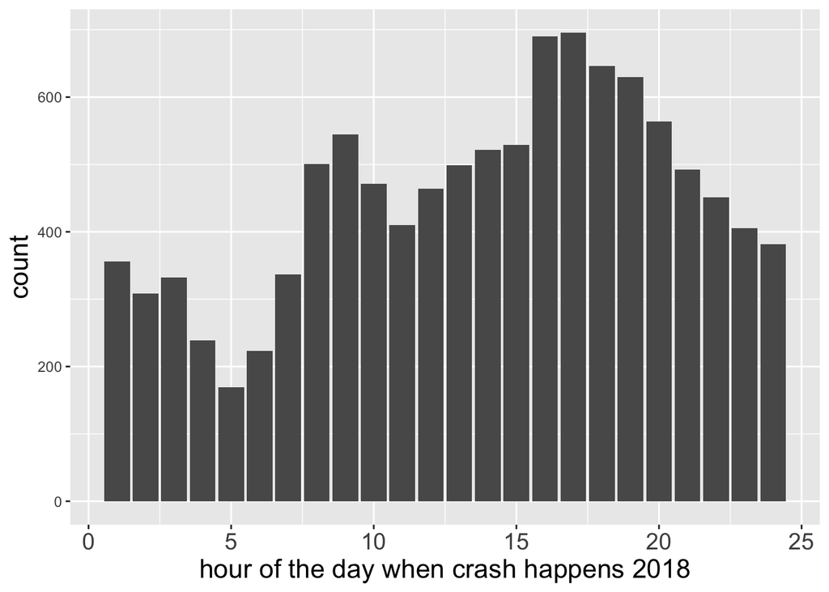

```r
#no significant difference in number of car crashes among different day of week.
ggsave("dayofweek18.tiff",plot=fig1)
library(dplyr)
flag.2018 %>%
    mutate(HOUR_OF_DAY = ifelse(HOUR_OF_DAY %in% c(99), NA,factor(HOUR_OF_DAY))) %>%
    ggplot(aes(x = HOUR_OF_DAY))+
    geom_bar()+
    labs(x = "hour of the day when crash happens 2018")+
    My_Theme+
    ggsave("hourofday18.tiff")
```

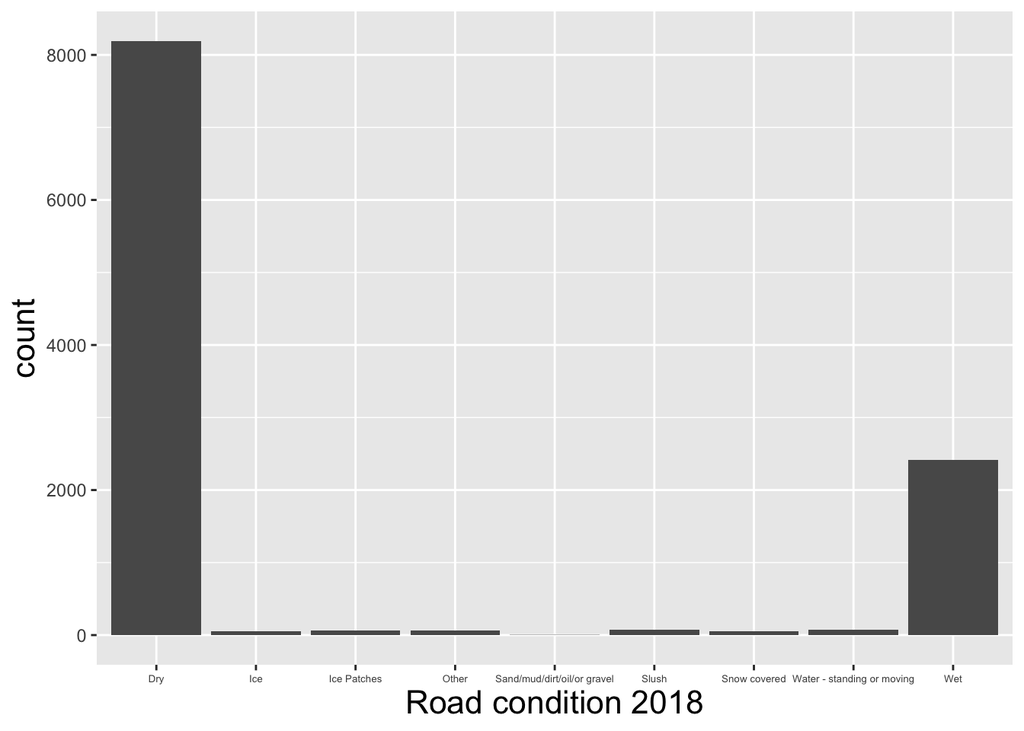

```r
# Peak hour of crashes: from 8-9AM in the morning, and from 4-8PM in the afternoon.

flag.2018 %>%
    ggplot(aes(x = ROAD_CONDITION))+
    geom_bar()+
    labs(x = "Road condition 2018")+
    My_Theme.2+
    ggsave("Roadcondition18.tiff") #Mostly happens on dry roads, and wet roads are the second contributing factors.
```

```r
nrow(flag.2018)
```

```
## [1] 11003
```

```r
flag.2018%>%
  group_by(ROAD_CONDITION)%>%
  count(ROAD_CONDITION)
```

```
## # A tibble: 9 x 2
## # Groups:   ROAD_CONDITION [9]
##   ROAD_CONDITION                  n
##   <fct>                       <int>
## 1 Dry                          8194
## 2 Ice                            58
## 3 Ice Patches                    60
## 4 Other                          64
## 5 Sand/mud/dirt/oil/or gravel     4
## 6 Slush                          71
## 7 Snow covered                   57
## 8 Water - standing or moving     79
## 9 Wet                          2416
```

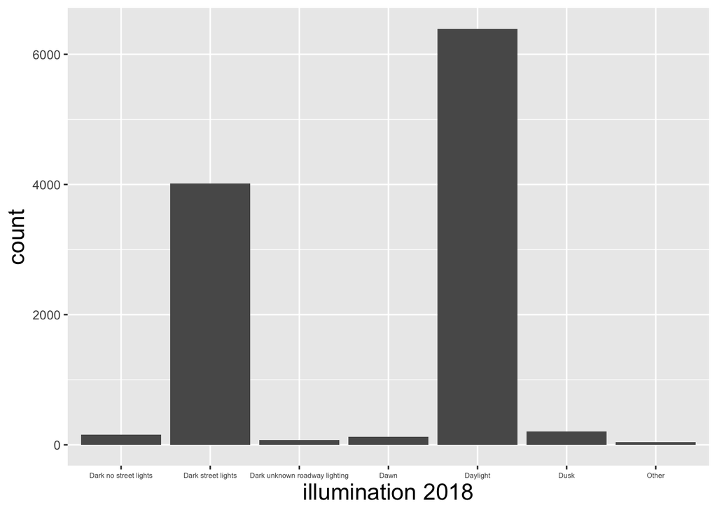

```r
#There are 207 sunny days in Philadelphia. 158 non-sunny days.

flag.2018 %>%
    ggplot(aes(x = ILLUMINATION))+
    geom_bar()+
    labs(x = "illumination 2018")+
    My_Theme.2+
    ggsave("illumination18.tiff") #Mostly happens on daylight, and dark with street lights are the second common.
```

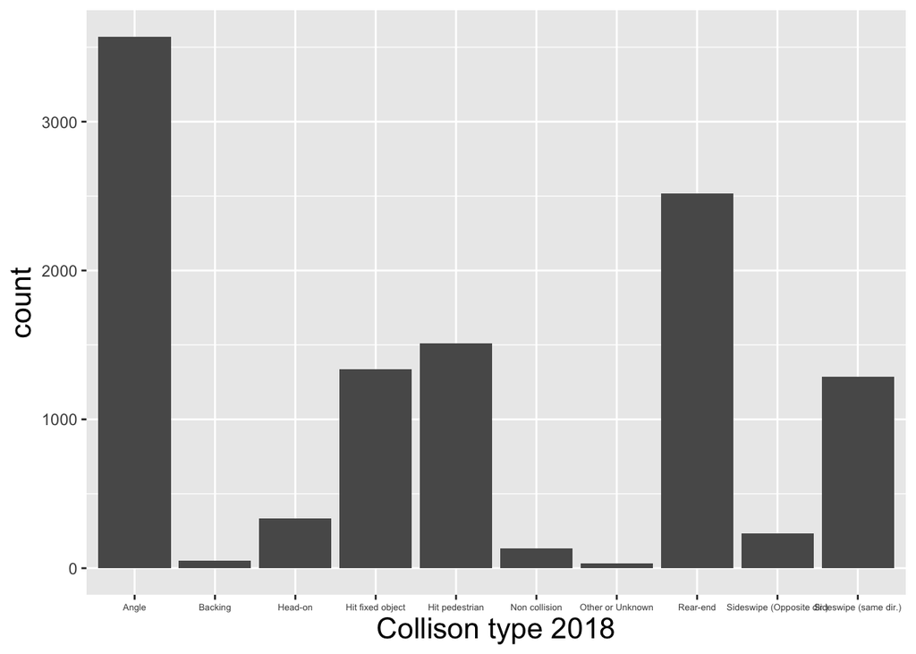

```r
flag.2018 %>%
    ggplot(aes(x = factor(COLLISION_TYPE)))+
    geom_bar()+
    labs(x = "Collison type 2018")+
    My_Theme.2+
    ggsave("Collisontype18.tiff") #First likely at an angle, second likely: rear-end
```

```r
flag.2018 %>%
  group_by(COLLISION_TYPE)%>%
  count(COLLISION_TYPE)
```

```
## # A tibble: 10 x 2
## # Groups:   COLLISION_TYPE [10]
##    COLLISION_TYPE                n
##    <fct>                     <int>
##  1 Angle                      3572
##  2 Backing                      50
##  3 Head-on                     334
##  4 Hit fixed object           1335
##  5 Hit pedestrian             1512
##  6 Non collision               131
##  7 Other or Unknown             33
##  8 Rear-end                   2517
##  9 Sideswipe (Opposite dir.)   234
## 10 Sideswipe (same dir.)      1285
```

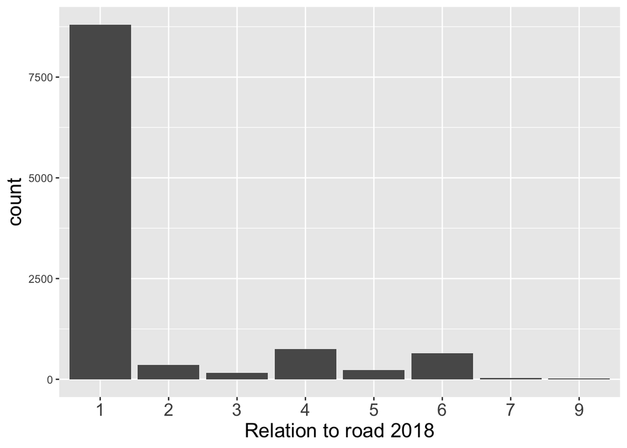

```r
crash.2018 %>%
    ggplot(aes(x = factor(RELATION_TO_ROAD)))+
    geom_bar()+
    labs(x = "Relation to road 2018")+
    My_Theme+
    ggsave("Relation to road 18.tiff") #Mostly on roadway.
```

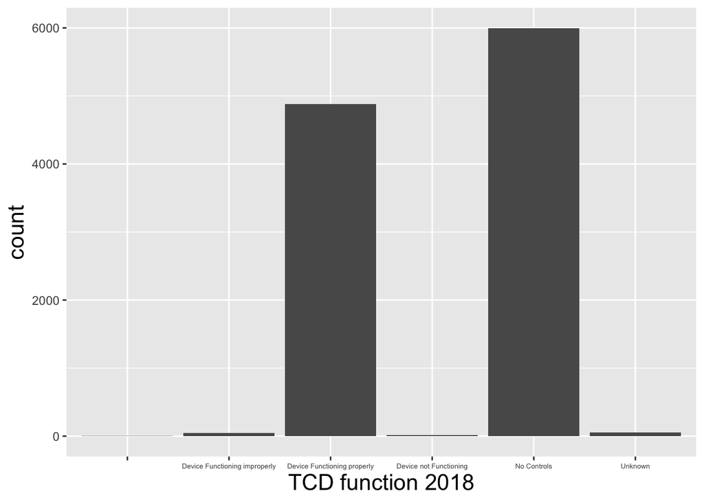

```r
flag.2018 %>%
    ggplot(aes(x = factor(TCD_FUNC_CD)))+
    geom_bar()+
    labs(x = "TCD function 2018")+
    My_Theme.2+
    ggsave("TCD18.tiff")
```

```r
flag.2018 %>%
  group_by(TCD_FUNC_CD)%>%
  count(TCD_FUNC_CD)#About 4878/11003=0.44%: device functioning properly, another 5998/11003=0.55%:with no controls
```

```
## # A tibble: 6 x 2
## # Groups:   TCD_FUNC_CD [6]
##   TCD_FUNC_CD                       n
##   <fct>                         <int>
## 1 ""                                4
## 2 Device Functioning improperly    48
## 3 Device Functioning properly    4878
## 4 Device not Functioning           19
## 5 No Controls                    5998
## 6 Unknown                          56
```

```r
nrow(flag.2018) #11003 accidents.
```

```
## [1] 11003
```

### Dicussion of part I

For the first part of looking at objective variables, I found the following results: There are 10676 crashes in 2008, and 11003 crashes in 2018. The increase of crashes is probably due to the increase number of vehicles in Philadelphia.

For the day of the week, Saturdays have more crashes in both 2008 and 2018. The crashes are least likely to happen on Mondays for 2008, Thurdays for 2018.

For the hour of the day, afternoons have more crashes in both years from the histograms. In addition, for 2008, the peak hours for crashes in the moring are 8-10 AM, and the peak hours for crashes in the afternoons are 5-7PM. For 2018, the peak hours for crashes are 8-9AM, 4-8PM. The peak hours are highly correlated to rush hours of traffic in Philadelphia, before and after work.

For road conditions, most crashes happened on dry roads, but about 20% of crashes happened on wet roads.

For Collison types, the three most common types and percentages are: 32% crashes happened at an angle, 23% crashes happened at rear-end, 14% crashes hit pedestrians.